# Term Deposits Case Study (EDA-1)

# 1. Problem Statement

## 1.1 Background Infromation

A bank is going to offer term deposit to its customers. A term deposit is basically investing an amount of money into the bank for fixed term or length of time or for a fixed term at a fixed rate. Of course the banks love that because it’s sort of income for them and then they can reinvest it themselves and make money on it. In this regard, the bank is planning to launch a marketing campaign to target its customers. In the past, the bank ran marketing campaigns and connected to their customer base through telemarketing. Results of these previous campaigns were recorded and have been provided to the current marketing manager to use the same in making this campaign more effective.

## 1.2 Challenges at hand

Challenges that the marketing manager faces are following:

- Customers have recently started to complain that bank’s marketing staff bothers them with irrelevant product calls and this should immediately stop.
- There is no prior framework for the marketing manager to decide and choose which customer to call and which one to leave alone.

## 1.3 Current Scenario

So this case study is actually for a bank that has a marketing group and this marketing team, what they’re trying to do is determine whether or not people are going to be likely or not to enroll them a term deposit. The manager has decided to use past data to automate this decision, instead of manually choosing through each and every customer. Previous campaign data which has been made available contains customer characteristics, campaign characteristics, previous campaign information as well as whether customer ended up subscribing to the product as a result of that campaign or not.

## 1.4 Plan of Action

In this business process, we’re going to take some data that we know about these customers and we’re going to try and correlate it to whether or not those customers have either opted in or not opted into the term deposit program and come up with a marketing analysis. Using this, the marketing manager plans to develop a statistical model which, given this information, predicts whether customer in question will subscribe to the product or not. A successful model which is able to do this, will make the campaign efficiently targeted and less bothering to uninterested customers.

## 1.5 End Result

The whole marketing piece to this is trying to reach out to customers to determine if they’re interested in the term deposit. At the end, if the conversion rate is high then the marketing campaign turns out to be successful which might reflect in the quarterly profits of the bank. Hence, the marketing manager can expect a bonus or hike in the next appraisal.

# 2. Study Questions

- **What are the factors that will make the camapign successful?**
- **How will the current campaign be different from the previous ones?**
- **What is the strategy that we are going to opt in?**

# 3. Business Process

1. We are going to collect some **client data** from various sources.
2. We are going to merge that data together in Excel using **VLOOKUP**.
3. Once it’s all blended together, we will take that data and then try and come up with a **marketing analysis**.
4. Finally, we will come up with a **strategy**.

# 4. Loading Packages and Libraries

Alright! lets begin our marketing analytics by installing some packages and loading all the libraries.

```r
library(tidyverse)
```

Library **tidyverse** loads a bunch of packages like **ggplot2** which is used for visualization and **dplyr** is used for manipulation and several other packages.

```r
library(readxl)
```

**readxl** package is going to allow us to read Excel files.

```r
library(recipes)
```

**recipes** package is kind of an advanced package but, its really useful for preparing data and adding various manipulations to it.

```r
library(tidyquant)
```

The **tidyquant** package is primarily going to used for some plotting. It has got some nice themes in there.

`r`r library(ggrepel)

**ggrepel** is also a nice package for adding lines to show where different labels kind of connect up with the data points.

`r`r library(gridExtra)

# 5. Marketing Analytics Process

**Marketing analytics** is the process of measuring, managing and analyzing marketing performance to maximize its effectiveness and optimize return on investment (ROI). Understanding marketing analytics allows marketers to be more efficient at their jobs and minimize wasted web marketing dollars.

## 5.1 Importing Data

Let me first setup the working directory.

```r
setwd("C:/Users/msrra/Desktop/INSAID/DAR/EDA")
```

Now, lets import our data.

```r
dataset = "C:/Users/msrra/Desktop/INSAID/DAR/EDA/bank_term_deposit_marketing_analysis.xlsx"
```

## 5.2 Reading Data

Our client information is stored in different excel sheets. Lets load those excel sheets from our current working directory. We’re gonna use this **excel sheets** function and that comes from the readxl package to save the sheets.

```r
sheets = excel_sheets(dataset)
```

It saves the sheets. So if I output the sheets to the screen and you can see we’ve got all of the excel sheets that are in that excel file. ___

What this is going to allow me to do is then target specific excel sheets to pull in. So, when I look at this, what I can see is that there are different steps here.

```r
sheets
```

```
 [1] "PROCEDURE"                    "DATA DESCRIPTION"             "Step 1 - Collect Information"
 [4] "CLIENT_INFO"                  "LOAN_HISTORY"                 "MARKETING HISTORY"
 [7] "SUBSCRIPTION HISTORY"         "Step 2 - Merge Information"   "CLIENT_MERGE"
[10] "Step 3 - Marketing Analysis"  "DAILY RANGE"                  "JOB ANALYSIS"
[13] "Sheet3"
```

In the first step, there is **client info**, **loan history**, **marketing history**, and **subscription history**. So thats the data that is used to be joined in the second step client merge and then in the third step we perform the marketing analysis.

## 5.3 Investigating Data

Actually, we iterate through each one of the sheets and pull them into R. We use this piece of code here to **map** through this **readxl** and apply that **read_excel** function to each one of these sheets. So, now I can actually see what’s in each of the different Excel tabs.

```r
sheets %>%
    map(~ read_excel(path  = dataset, sheet = .)) %>%
    set_names(sheets)
```

```
* `` -> ...2
* `` -> ...3
* `` -> ...4
* `` -> ...5
* `` -> ...6
* ... and 14 more problems
* `` -> ...2
* `` -> ...4
```

| BANK MARKETING ANALYSIS PROCEDURE |
| --- |
| NA |
| STEP 1: COLLECT INFORMATION |
| 1) CLIENT INFORMATION: AGE, JOB, MARITAL STATUS, EDUCATION LEVEL |
| 2) CLIENT LOAN HISTORY: DEFAULT HISTORY, HOME LOAN, PERSONAL LOAN, CURRENT BALANCE |
| 3) MARKETING HISTORY: CONTACT TYPE, DAY LAST CONTACT, MONTH LAST CONTACT, LAST CONTACT DURATION |
| 4) SUBSCRIPTION HISTORY: ENROLLED IN TERM LOAN? (Y/N) |
| NA |
| STEP 2: MERGE INFORMATION |
| 1) PERFORM VLOOKUP |
| NA |

[output cut: 4 more lines]

```
$`DATA DESCRIPTION`
```

| bank_info |
| --- |
| Citation Request: |
| This dataset is public available for research. The details are described in [Moro et al., 2011]. |
| Please include this citation if you plan to use this database: |
| NA |
| [Moro et al., 2011] S. Moro, R. Laureano and P. Cortez. Using Data Mining for Bank Direct Marketing: An Application of the CRISP-DM Methodology. |
| In P. Novais et al. (Eds.), Proceedings of the European Simulation and Modelling Conference - ESM'2011, pp. 117-121, Guimarães, Portugal, October, 2011. EUROSIS. |
| NA |
| Available at: [pdf] http://hdl.handle.net/1822/14838 |
| [bib] http://www3.dsi.uminho.pt/pcortez/bib/2011-esm-1.txt |
| NA |

[output cut: 60 more lines]

```
$`Step 1 - Collect Information`
```

| Step | Description |
| --- | --- |
| 1 | Collect Client Information |

| ID | AGE | JOB | MARITAL | EDUCATION |
| --- | --- | --- | --- | --- |
| 2836 | 58 | management | married | tertiary |
| 2837 | 44 | technician | single | secondary |
| 2838 | 33 | entrepreneur | married | secondary |
| 2839 | 47 | blue-collar | married | unknown |
| 2840 | 33 | unknown | single | unknown |
| 2841 | 35 | management | married | tertiary |
| 2842 | 28 | management | single | tertiary |
| 2843 | 42 | entrepreneur | divorced | tertiary |
| 2844 | 58 | retired | married | primary |
| 2845 | 43 | technician | single | secondary |

[output cut: 990 more lines]

| ID | DEFAULT | BALANCE | HOUSING | LOAN |
| --- | --- | --- | --- | --- |
| 2836 | no | 2143 | yes | no |
| 2837 | no | 29 | yes | no |
| 2838 | no | 2 | yes | yes |
| 2839 | no | 1506 | yes | no |
| 2840 | no | 1 | no | no |
| 2841 | no | 231 | yes | no |
| 2842 | no | 447 | yes | yes |
| 2843 | yes | 2 | yes | no |
| 2844 | no | 121 | yes | no |
| 2845 | no | 593 | yes | no |

[output cut: 990 more lines]

```
$`MARKETING HISTORY`
```

| ID | CONTACT | DAY | MONTH | DURATION | CAMPAIGN | PDAYS | PREVIOUS | POUTCOME |
| --- | --- | --- | --- | --- | --- | --- | --- | --- |
| 2836 | unknown | 5 | may | 261 | 1 | -1 | 0 | unknown |
| 2837 | unknown | 5 | may | 151 | 1 | -1 | 0 | unknown |
| 2838 | unknown | 5 | may | 76 | 1 | -1 | 0 | unknown |
| 2839 | unknown | 5 | may | 92 | 1 | -1 | 0 | unknown |
| 2840 | unknown | 5 | may | 198 | 1 | -1 | 0 | unknown |
| 2841 | unknown | 5 | may | 139 | 1 | -1 | 0 | unknown |
| 2842 | unknown | 5 | may | 217 | 1 | -1 | 0 | unknown |
| 2843 | unknown | 5 | may | 380 | 1 | -1 | 0 | unknown |
| 2844 | unknown | 5 | may | 50 | 1 | -1 | 0 | unknown |
| 2845 | unknown | 5 | may | 55 | 1 | -1 | 0 | unknown |

[output cut: 990 more lines]

```
$`SUBSCRIPTION HISTORY`
```

| ID | TERM_DEPOSIT |
| --- | --- |
| 2836 | no |
| 2837 | no |
| 2838 | no |
| 2839 | no |
| 2840 | no |
| 2841 | no |
| 2842 | no |
| 2843 | no |
| 2844 | no |
| 2845 | no |

[output cut: 990 more lines]

```
$`Step 2 - Merge Information`
```

| Step | Description |
| --- | --- |
| 2 | Perform Data Merge |

| VLOOKUP MERGE - BAD FOR A NUMBER OF REASONS | ...2 | ...3 | ...4 | ...5 | ...6 | ...7 | ...8 | ...9 | ...10 | ...11 | ...12 | ...13 | ...14 | ...15 | ...16 | ...17 | ...18 | ...19 | ...20 |
| --- | --- | --- | --- | --- | --- | --- | --- | --- | --- | --- | --- | --- | --- | --- | --- | --- | --- | --- | --- |
| 1. DIFFICULT TO TELL IF VLOOKUP WAS DONE PROPERLY - QA NIGHTMARE | NA | NA | NA | NA | NA | NA | NA | NA | NA | NA | NA | NA | NA | NA | NA | NA | NA | NA | NA |
| 2. COMPUTATIONALLY INTENSE FOR EXCEL - HAD TO LIMIT TO 10K ROWS - EXCEL TIMED OUT ON FULL DATASET (50K ROWS) | NA | NA | NA | NA | NA | NA | NA | NA | NA | NA | NA | NA | NA | NA | NA | NA | NA | NA | NA |
| 3. EVERY CELL CONTAINS FUNCTION - MAKES FILE SIZES HUGE (20% DATA INCREASED FILE SIZE FROM 4MB TO 7.2MB) | NA | NA | NA | NA | NA | NA | NA | NA | NA | NA | NA | NA | NA | NA | NA | NA | NA | NA | NA |
| NA | NA | NA | NA | NA | NA | NA | NA | NA | NA | NA | NA | NA | NA | NA | NA | NA | NA | NA | NA |
| NA | CLIENT_INFO | NA | NA | NA | LOAN_HISTORY | NA | NA | NA | MARKETING_HISTORY | NA | NA | NA | NA | NA | NA | NA | SUBSCRIPTION_HISTORY | CALCULATED COLUMNS | NA |
| NA | 2.0 | 3.0 | 4.0 | 5.0 | 2.0 | 3.0 | 4.0 | 5.0 | 2.0 | 3.0 | 4.0 | 5.0 | 6.0 | 7.0 | 8.0 | 9.0 | 2.0 | NA | NA |
| ID | AGE | JOB | MARITAL | EDUCATION | DEFAULT | BALANCE | HOUSING | LOAN | CONTACT | DAY | MONTH | DURATION | CAMPAIGN | PDAYS | PREVIOUS | POUTCOME | TERM_DEPOSIT | TERM_DEPOSIT_BINARY | COUNT |
| 2836 | 58 | management | married | tertiary | no | 2143 | yes | no | unknown | 5 | may | 261 | 1 | -1 | 0 | unknown | no | 0 | 1.0 |
| 2837 | 44 | technician | single | secondary | no | 29 | yes | no | unknown | 5 | may | 151 | 1 | -1 | 0 | unknown | no | 0 | 1.0 |
| 2838 | 33 | entrepreneur | married | secondary | no | 2 | yes | yes | unknown | 5 | may | 76 | 1 | -1 | 0 | unknown | no | 0 | 1.0 |

[output cut: 990 more lines]

```
$`Step 3 - Marketing Analysis`
```

| Step | Description |
| --- | --- |
| 3 | Perform Marketing Analysis |

```
$`DAILY RANGE`
```

| HIT RATE | ...2 | DAILY SUMMARY | ...4 |
| --- | --- | --- | --- |
| 0.038560411 | NA | MEAN | 0.035121428 |
| 0.036011080 | NA | MEDIAN | 0.036199095 |
| 0.055118110 | NA | SD | 0.013788032 |
| 0.061281337 | NA | LOWER CONF | 0.007545364 |
| 0.042713568 | NA | UPPER CONF | 0.062697493 |
| 0.039145907 | NA | NA | NA |
| 0.045053869 | NA | NA | NA |
| 0.016620499 | NA | NA | NA |
| 0.022222222 | NA | NA | NA |
| 0.017948718 | NA | NA | NA |

[output cut: 18 more lines]

```
$`JOB ANALYSIS`
```

```
NA
```

Recognizing that there’s only a few sheets that we want i.e. **client info**, **loan history**, **marketing history**, and **subscription history**.

```r
sheets[4:7]
```

```
[1] "CLIENT_INFO"          "LOAN_HISTORY"         "MARKETING HISTORY"    "SUBSCRIPTION HISTORY"
```

This is the feeder data that is used to be joined in the client merge step and then in the third step we perform the marketing analysis.

What we can do is just kind of extract those sheets specifically which is what this line of code does and it just read in each one.

`r`r sheets[4:7] %>% map(~read_excel(path = dataset, sheet = .))

| ID | AGE | JOB | MARITAL | EDUCATION |
| --- | --- | --- | --- | --- |
| 2836 | 58 | management | married | tertiary |
| 2837 | 44 | technician | single | secondary |
| 2838 | 33 | entrepreneur | married | secondary |
| 2839 | 47 | blue-collar | married | unknown |
| 2840 | 33 | unknown | single | unknown |
| 2841 | 35 | management | married | tertiary |
| 2842 | 28 | management | single | tertiary |
| 2843 | 42 | entrepreneur | divorced | tertiary |
| 2844 | 58 | retired | married | primary |
| 2845 | 43 | technician | single | secondary |

[output cut: 990 more lines]

| ID | DEFAULT | BALANCE | HOUSING | LOAN |
| --- | --- | --- | --- | --- |
| 2836 | no | 2143 | yes | no |
| 2837 | no | 29 | yes | no |
| 2838 | no | 2 | yes | yes |
| 2839 | no | 1506 | yes | no |
| 2840 | no | 1 | no | no |
| 2841 | no | 231 | yes | no |
| 2842 | no | 447 | yes | yes |
| 2843 | yes | 2 | yes | no |
| 2844 | no | 121 | yes | no |
| 2845 | no | 593 | yes | no |

[output cut: 990 more lines]

| ID | CONTACT | DAY | MONTH | DURATION | CAMPAIGN | PDAYS | PREVIOUS | POUTCOME |
| --- | --- | --- | --- | --- | --- | --- | --- | --- |
| 2836 | unknown | 5 | may | 261 | 1 | -1 | 0 | unknown |
| 2837 | unknown | 5 | may | 151 | 1 | -1 | 0 | unknown |
| 2838 | unknown | 5 | may | 76 | 1 | -1 | 0 | unknown |
| 2839 | unknown | 5 | may | 92 | 1 | -1 | 0 | unknown |
| 2840 | unknown | 5 | may | 198 | 1 | -1 | 0 | unknown |
| 2841 | unknown | 5 | may | 139 | 1 | -1 | 0 | unknown |
| 2842 | unknown | 5 | may | 217 | 1 | -1 | 0 | unknown |
| 2843 | unknown | 5 | may | 380 | 1 | -1 | 0 | unknown |
| 2844 | unknown | 5 | may | 50 | 1 | -1 | 0 | unknown |
| 2845 | unknown | 5 | may | 55 | 1 | -1 | 0 | unknown |

[output cut: 990 more lines]

```
NA
```

| ID | TERM_DEPOSIT |
| --- | --- |
| 2836 | no |
| 2837 | no |
| 2838 | no |
| 2839 | no |
| 2840 | no |
| 2841 | no |
| 2842 | no |
| 2843 | no |
| 2844 | no |
| 2845 | no |

[output cut: 990 more lines]

You can see we’ve got **age**, **job**, you know what is their job, what is their **marital** status, are they single, married, divorced, and education level and so on.

## 5.4 Perform VLOOKUP Equivalent

We’re going to apply this **left join** function which is going to take the **ID** column since they all have ID and it’s basically going to accomplish the **VLOOKUP** for us.

`r`r data_joined_tbl <- sheets[4:7] %>% map(~ read_excel(path = dataset, sheet = .)) %>% reduce(left_join)

What we did was as you can see is joining by ID. So, by using this left join and doing this **reduce**, it’s iteratively joining each of those data frames and saved it as this variable called **data_joined_tbl**

Here’s what it looks like.

`r`r data_joined_tbl

| ID | AGE | JOB | MARITAL | EDUCATION | DEFAULT | BALANCE | HOUSING | LOAN | CONTACT | DAY | MONTH | DURATION | CAMPAIGN | PDAYS | PREVIOUS | POUTCOME | TERM_DEPOSIT |
| --- | --- | --- | --- | --- | --- | --- | --- | --- | --- | --- | --- | --- | --- | --- | --- | --- | --- |
| 2836 | 58 | management | married | tertiary | no | 2143 | yes | no | unknown | 5 | may | 261 | 1 | -1 | 0 | unknown | no |
| 2837 | 44 | technician | single | secondary | no | 29 | yes | no | unknown | 5 | may | 151 | 1 | -1 | 0 | unknown | no |
| 2838 | 33 | entrepreneur | married | secondary | no | 2 | yes | yes | unknown | 5 | may | 76 | 1 | -1 | 0 | unknown | no |
| 2839 | 47 | blue-collar | married | unknown | no | 1506 | yes | no | unknown | 5 | may | 92 | 1 | -1 | 0 | unknown | no |
| 2840 | 33 | unknown | single | unknown | no | 1 | no | no | unknown | 5 | may | 198 | 1 | -1 | 0 | unknown | no |
| 2841 | 35 | management | married | tertiary | no | 231 | yes | no | unknown | 5 | may | 139 | 1 | -1 | 0 | unknown | no |
| 2842 | 28 | management | single | tertiary | no | 447 | yes | yes | unknown | 5 | may | 217 | 1 | -1 | 0 | unknown | no |
| 2843 | 42 | entrepreneur | divorced | tertiary | yes | 2 | yes | no | unknown | 5 | may | 380 | 1 | -1 | 0 | unknown | no |
| 2844 | 58 | retired | married | primary | no | 121 | yes | no | unknown | 5 | may | 50 | 1 | -1 | 0 | unknown | no |
| 2845 | 43 | technician | single | secondary | no | 593 | yes | no | unknown | 5 | may | 55 | 1 | -1 | 0 | unknown | no |

[output cut: 990 more lines]

Lets view the merged data.

`r`r View(data_joined_tbl)

## 5.5 Analyze Data

### 5.5.1 Is there any seasonality in the dataset?

There are three distinct seasons addressing the number of contacts of the current marketing campaign:

- High Season - Period with high number of contacts: May to Aug
- Medium Season - Period with medium number of contacts: Feb, Apr, Nov
- Low Season - Period with low number of contacts: Jan, Mar, Sept, Oct, Dec

`r`r p = ggplot(data_joined_tbl, aes(x = MONTH, y = CAMPAIGN, color = TERM_DEPOSIT)) p+geom_jitter()

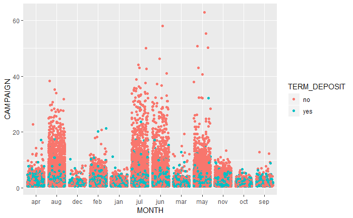

### 5.5.2 Which age group is targeted the most?

Two distinct age groups addressing the number of contacts of the current market campaign:

- The number of contacts drops dramatically at around 62 years old
- A new categorical variable will be created to address these two groups

`r`r p = ggplot(data_joined_tbl, aes(x = AGE, y = CAMPAIGN, color = TERM_DEPOSIT)) p+geom_jitter()

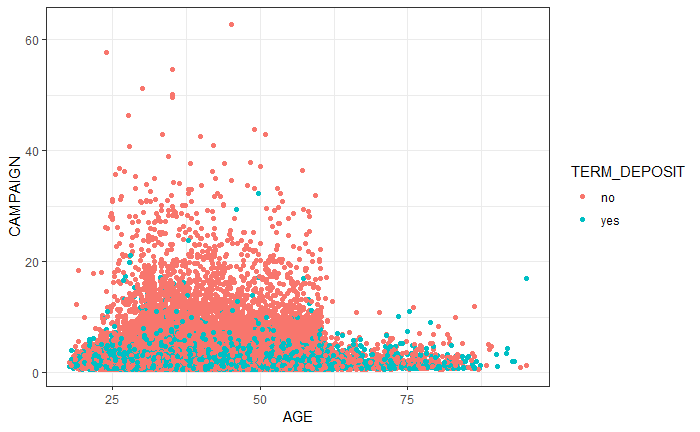

Lets see if there is any relationship between customer subscribed to term deposit and customer age.

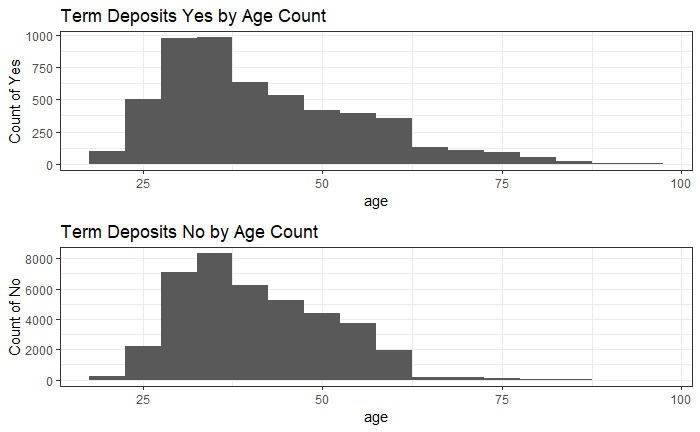

These plots makes me think that age probably doesn’t have much to do with our variable of interest

### 5.5.3 Which job category enrolled for term deposit?

Lets see what kind of **job categories** opted in for term deposit.

`r`r jobs = ggplot(data = data_joined_tbl) + geom_bar( mapping = aes(x = JOB, fill = TERM_DEPOSIT), width = 0.9 ) + theme(aspect.ratio = 1) + labs(x = NULL, y = NULL) jobs + coord_flip()

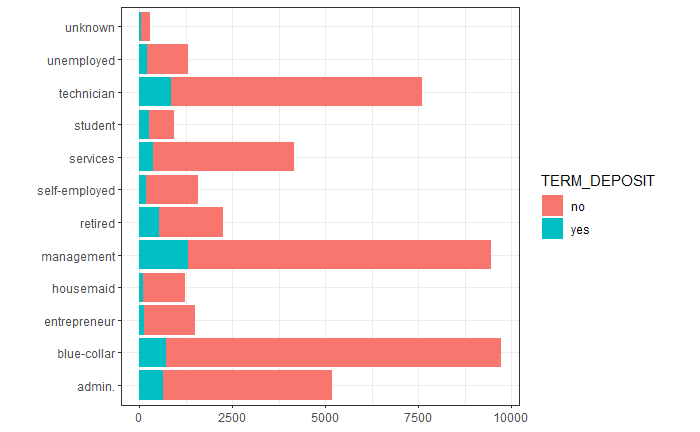

### 5.5.4 What are the education levels of customers opted in?

Lets plot **education level** vs **term deposit** on a chart and see if there is anything interesting there.

`r`r ggplot(data_joined_tbl, aes(EDUCATION, TERM_DEPOSIT)) + geom_jitter()

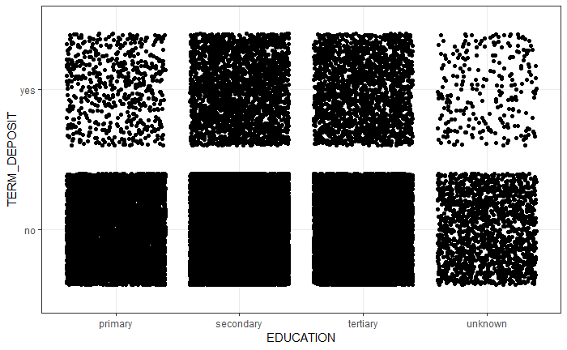

This again doesn’t look all that meaninful. Relatively speaking, the “yes’s” and the “no’s” seem to line up relatively evenly across educational levels.

### 5.5.5 Is marital status really significant?

Now, we’ll do **single** vs **married** folks

`r`r ggplot(data_joined_tbl, aes(MARITAL, TERM_DEPOSIT)) + geom_jitter()

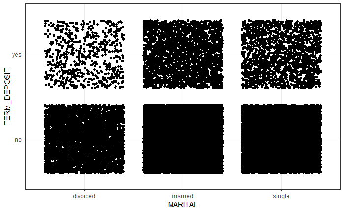

### 5.5.6 Whether the customer has credit in default?

How about **default yes/no** vs the **term deposit**?

`r`r ggplot(data_joined_tbl, aes(DEFAULT, TERM_DEPOSIT)) + geom_jitter()

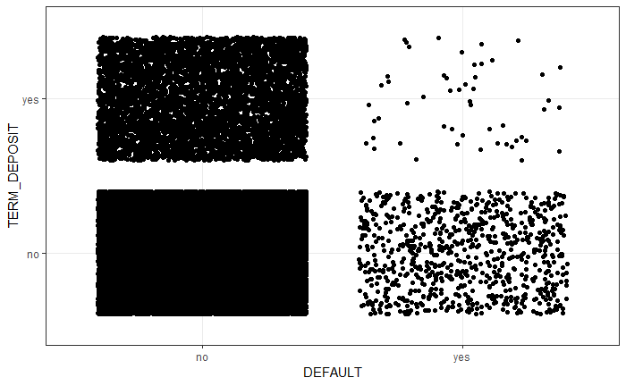

## 5.6 Prepare Data

We have applied this **glimpse** function to our data so we can actually see a little bit better all eighteen columns.

The problem with this data is, we can’t run a **correlation analysis** on it. We have to transform these variables into all binary or all numeric. We are going to use the **recipes** package to do that. ___

I’m gonna show you how the recipes package works:

- First is the **recipe** function
- Then there’s a **prep** function
- A bunch of **steps** applied in the middle to do some transformations
- And then there’s a **bake** function

If we run this chunk of code here, it’s not going to do any transformation but, it’s gonna build a recipe. So, I’m going to build this recipe object. and

`r`r recipe_obj = recipe(~ ., data = data_joined_tbl) %>% prep()

If you see, it doesn’t have any steps applied here but, it’s got a role that’s a predictor and it’s got eighteen variables.

`r`r recipe_obj

```
Data Recipe

Inputs:

Training data contained 45211 data points and no missing data.
```

| role | #variables |
| --- | --- |
| predictor | 18 |

when we apply **bake** for the data transform and give it the new data which is going to be this data_joined_tbl, what bake does is, it actually takes that recipe that we built up here and applies that to the data.

`r`r data_transformed_tbl = data_joined_tbl %>% bake(recipe_obj, new_data = .)

We’re coming up with a recipe and then we’re applying that recipe to a dataset. So, if we run this, it actually doesn’t do any transformation because we don’t have any steps in here in the middle.

We haven’t really come up with a recipe yet and we can verify that because the **data_transformed_tbl** variable is the same as the **data_joined_tbl** variable.

`r`r glimpse(data_transformed_tbl)

```
Observations: 45,211
Variables: 18
$ ID           <fct> 2836, 2837, 2838, 2839, 2840, 2841, 2842, 2843, 2844, 2845, 2846, 2847, 2...
$ AGE          <dbl> 58, 44, 33, 47, 33, 35, 28, 42, 58, 43, 41, 29, 53, 58, 57, 51, 45, 57, 6...
$ JOB          <fct> management, technician, entrepreneur, blue-collar, unknown, management, m...
$ MARITAL      <fct> married, single, married, married, single, married, single, divorced, mar...
$ EDUCATION    <fct> tertiary, secondary, secondary, unknown, unknown, tertiary, tertiary, ter...
$ DEFAULT      <fct> no, no, no, no, no, no, no, yes, no, no, no, no, no, no, no, no, no, no, ...
$ BALANCE      <dbl> 2143, 29, 2, 1506, 1, 231, 447, 2, 121, 593, 270, 390, 6, 71, 162, 229, 1...
$ HOUSING      <fct> yes, yes, yes, yes, no, yes, yes, yes, yes, yes, yes, yes, yes, yes, yes,...
$ LOAN         <fct> no, no, yes, no, no, no, yes, no, no, no, no, no, no, no, no, no, no, no,...
$ CONTACT      <fct> unknown, unknown, unknown, unknown, unknown, unknown, unknown, unknown, u...
$ DAY          <dbl> 5, 5, 5, 5, 5, 5, 5, 5, 5, 5, 5, 5, 5, 5, 5, 5, 5, 5, 5, 5, 5, 5, 5, 5, 5...
$ MONTH        <fct> may, may, may, may, may, may, may, may, may, may, may, may, may, may, may...
$ DURATION     <dbl> 261, 151, 76, 92, 198, 139, 217, 380, 50, 55, 222, 137, 517, 71, 174, 353...
$ CAMPAIGN     <dbl> 1, 1, 1, 1, 1, 1, 1, 1, 1, 1, 1, 1, 1, 1, 1, 1, 1, 1, 1, 1, 1, 1, 1, 1, 1...
$ PDAYS        <dbl> -1, -1, -1, -1, -1, -1, -1, -1, -1, -1, -1, -1, -1, -1, -1, -1, -1, -1, -...
$ PREVIOUS     <dbl> 0, 0, 0, 0, 0, 0, 0, 0, 0, 0, 0, 0, 0, 0, 0, 0, 0, 0, 0, 0, 0, 0, 0, 0, 0...
$ POUTCOME     <fct> unknown, unknown, unknown, unknown, unknown, unknown, unknown, unknown, u...
$ TERM_DEPOSIT <fct> no, no, no, no, no, no, no, no, no, no, no, no, no, no, no, no, no, no, n...
```

Alright! so the first thing we going to do is to add a **step**, we are going to remove this ID feature because that is not going to give us any information.

`r`r recipe_obj <- recipe(~ ., data = data_joined_tbl) %>% step_rm(ID) %>% prep()

We are going to run this again.

`r`r data_transformed_tbl <- data_joined_tbl %>% bake(recipe_obj, new_data = .)

Now, we can see that there’s only 17 variables and that ID feature has been dropped.

`r`r glimpse(data_transformed_tbl)

```
Observations: 45,211
Variables: 17
$ AGE          <dbl> 58, 44, 33, 47, 33, 35, 28, 42, 58, 43, 41, 29, 53, 58, 57, 51, 45, 57, 6...
$ JOB          <fct> management, technician, entrepreneur, blue-collar, unknown, management, m...
$ MARITAL      <fct> married, single, married, married, single, married, single, divorced, mar...
$ EDUCATION    <fct> tertiary, secondary, secondary, unknown, unknown, tertiary, tertiary, ter...
$ DEFAULT      <fct> no, no, no, no, no, no, no, yes, no, no, no, no, no, no, no, no, no, no, ...
$ BALANCE      <dbl> 2143, 29, 2, 1506, 1, 231, 447, 2, 121, 593, 270, 390, 6, 71, 162, 229, 1...
$ HOUSING      <fct> yes, yes, yes, yes, no, yes, yes, yes, yes, yes, yes, yes, yes, yes, yes,...
$ LOAN         <fct> no, no, yes, no, no, no, yes, no, no, no, no, no, no, no, no, no, no, no,...
$ CONTACT      <fct> unknown, unknown, unknown, unknown, unknown, unknown, unknown, unknown, u...
$ DAY          <dbl> 5, 5, 5, 5, 5, 5, 5, 5, 5, 5, 5, 5, 5, 5, 5, 5, 5, 5, 5, 5, 5, 5, 5, 5, 5...
$ MONTH        <fct> may, may, may, may, may, may, may, may, may, may, may, may, may, may, may...
$ DURATION     <dbl> 261, 151, 76, 92, 198, 139, 217, 380, 50, 55, 222, 137, 517, 71, 174, 353...
$ CAMPAIGN     <dbl> 1, 1, 1, 1, 1, 1, 1, 1, 1, 1, 1, 1, 1, 1, 1, 1, 1, 1, 1, 1, 1, 1, 1, 1, 1...
$ PDAYS        <dbl> -1, -1, -1, -1, -1, -1, -1, -1, -1, -1, -1, -1, -1, -1, -1, -1, -1, -1, -...
$ PREVIOUS     <dbl> 0, 0, 0, 0, 0, 0, 0, 0, 0, 0, 0, 0, 0, 0, 0, 0, 0, 0, 0, 0, 0, 0, 0, 0, 0...
$ POUTCOME     <fct> unknown, unknown, unknown, unknown, unknown, unknown, unknown, unknown, u...
$ TERM_DEPOSIT <fct> no, no, no, no, no, no, no, no, no, no, no, no, no, no, no, no, no, no, n...
```

Next one is the step **discretize**, here we take the numeric variables and bin them into quantiles and then assess the correlation of the entire numeric variable like age. You can think of age as being cohorts some people are going to be younger some some are going to be middle-aged and some are going to be older we want to separate those three out into bins so that way we can assess those kind of like cohorts or the groups within the numeric features so that’s what this step is gonna do it’s going to convert all of these numeric variables like age

`r`r recipe_obj <- recipe(~ ., data = data_joined_tbl) %>% step_rm(ID) %>% step_discretize(all_numeric(), options = list(min_unique = 1)) %>% prep()

```
Not enough data for 4 breaks. Only 4 breaks were used.Not enough data for 4 breaks. Only 2 breaks were used.Not enough data for 4 breaks. Only 2 breaks were used.
```

We get some warnings here because some of the the variables can only be discretized into say two bins versus four bins or so on.

We will apply the bake again and then let’s see what that transformation looks like so now now that age vary is this thing called a factor it has FCT

`r`r data_transformed_tbl <- data_joined_tbl %>% bake(recipe_obj, new_data = .)

Now that age variable is called a **factor**, it has **fct**. All of the numeric variables got converted into factors or categorical data.

`r`r glimpse(data_transformed_tbl)

```
Observations: 45,211
Variables: 17
$ AGE          <fct> bin4, bin3, bin1, bin3, bin1, bin2, bin1, bin3, bin4, bin3, bin3, bin1, b...
$ JOB          <fct> management, technician, entrepreneur, blue-collar, unknown, management, m...
$ MARITAL      <fct> married, single, married, married, single, married, single, divorced, mar...
$ EDUCATION    <fct> tertiary, secondary, secondary, unknown, unknown, tertiary, tertiary, ter...
$ DEFAULT      <fct> no, no, no, no, no, no, no, yes, no, no, no, no, no, no, no, no, no, no, ...
$ BALANCE      <fct> bin4, bin1, bin1, bin4, bin1, bin2, bin2, bin1, bin2, bin3, bin2, bin2, b...
$ HOUSING      <fct> yes, yes, yes, yes, no, yes, yes, yes, yes, yes, yes, yes, yes, yes, yes,...
$ LOAN         <fct> no, no, yes, no, no, no, yes, no, no, no, no, no, no, no, no, no, no, no,...
$ CONTACT      <fct> unknown, unknown, unknown, unknown, unknown, unknown, unknown, unknown, u...
$ DAY          <fct> bin1, bin1, bin1, bin1, bin1, bin1, bin1, bin1, bin1, bin1, bin1, bin1, b...
$ MONTH        <fct> may, may, may, may, may, may, may, may, may, may, may, may, may, may, may...
$ DURATION     <fct> bin3, bin2, bin1, bin1, bin3, bin2, bin3, bin4, bin1, bin1, bin3, bin2, b...
$ CAMPAIGN     <fct> bin1, bin1, bin1, bin1, bin1, bin1, bin1, bin1, bin1, bin1, bin1, bin1, b...
$ PDAYS        <fct> bin1, bin1, bin1, bin1, bin1, bin1, bin1, bin1, bin1, bin1, bin1, bin1, b...
$ PREVIOUS     <fct> bin1, bin1, bin1, bin1, bin1, bin1, bin1, bin1, bin1, bin1, bin1, bin1, b...
$ POUTCOME     <fct> unknown, unknown, unknown, unknown, unknown, unknown, unknown, unknown, u...
$ TERM_DEPOSIT <fct> no, no, no, no, no, no, no, no, no, no, no, no, no, no, no, no, no, no, n...
```

Since we have categorical data for everything we can then apply this next step which is basically called **one hot encoding** which is going to turn all the categorical data and convert them into ones and zeros.

[output not shown]

Next we’re going to apply the transformation using the bake function. and

`r`r data_transformed_tbl <- data_joined_tbl %>% bake(recipe_obj, new_data = .)

We glimpse the data and we can see that now we have a lot more variables.

`r`r glimpse(data_transformed_tbl)

```
Observations: 45,211
Variables: 74
$ AGE__bin_missing      <dbl> 0, 0, 0, 0, 0, 0, 0, 0, 0, 0, 0, 0, 0, 0, 0, 0, 0, 0, 0, 0, 0, 0...
$ AGE__bin1             <dbl> 0, 0, 1, 0, 1, 0, 1, 0, 0, 0, 0, 1, 0, 0, 0, 0, 0, 0, 0, 1, 1, 0...
$ AGE__bin2             <dbl> 0, 0, 0, 0, 0, 1, 0, 0, 0, 0, 0, 0, 0, 0, 0, 0, 0, 0, 0, 0, 0, 0...
$ AGE__bin3             <dbl> 0, 1, 0, 1, 0, 0, 0, 1, 0, 1, 1, 0, 0, 0, 0, 0, 1, 0, 0, 0, 0, 0...
$ AGE__bin4             <dbl> 1, 0, 0, 0, 0, 0, 0, 0, 1, 0, 0, 0, 1, 1, 1, 1, 0, 1, 1, 0, 0, 1...
$ JOB__admin.           <dbl> 0, 0, 0, 0, 0, 0, 0, 0, 0, 0, 1, 1, 0, 0, 0, 0, 1, 0, 0, 0, 0, 0...
$ JOB__blue.collar      <dbl> 0, 0, 0, 1, 0, 0, 0, 0, 0, 0, 0, 0, 0, 0, 0, 0, 0, 1, 0, 0, 1, 0...
$ JOB__entrepreneur     <dbl> 0, 0, 1, 0, 0, 0, 0, 1, 0, 0, 0, 0, 0, 0, 0, 0, 0, 0, 0, 0, 0, 0...
$ JOB__housemaid        <dbl> 0, 0, 0, 0, 0, 0, 0, 0, 0, 0, 0, 0, 0, 0, 0, 0, 0, 0, 0, 0, 0, 0...
$ JOB__management       <dbl> 1, 0, 0, 0, 0, 1, 1, 0, 0, 0, 0, 0, 0, 0, 0, 0, 0, 0, 0, 0, 0, 1...
$ JOB__retired          <dbl> 0, 0, 0, 0, 0, 0, 0, 0, 1, 0, 0, 0, 0, 0, 0, 1, 0, 0, 1, 0, 0, 0...
$ JOB__self.employed    <dbl> 0, 0, 0, 0, 0, 0, 0, 0, 0, 0, 0, 0, 0, 0, 0, 0, 0, 0, 0, 0, 0, 0...
$ JOB__services         <dbl> 0, 0, 0, 0, 0, 0, 0, 0, 0, 0, 0, 0, 0, 0, 1, 0, 0, 0, 0, 1, 0, 0...
```

[output cut: 61 more lines]

So we have **74 variables** and they’re all binary, they’re all zeros and ones and you can see that this is the perfect dataset to apply a **correlation analysis**.

`r`r View(data_transformed_tbl)

## 5.7 Correlation Analysis

Since we’ve got this binary dataset now, we’re ready to do some correlations. We want to correlate all of these different variables to this **term deposit** feature and we’re going do that through this stepwise process.

### 5.7.1 Prepare Correlations

First, we will have a look at the **data_transformed_tbl**

`r`r data_transformed_tbl

| AGE__bin_missing | AGE__bin1 | AGE__bin2 | AGE__bin3 | AGE__bin4 | JOB__admin. | JOB__blue.collar | JOB__entrepreneur | JOB__housemaid | JOB__management | JOB__retired | JOB__self.employed | JOB__services | JOB__student | JOB__technician | JOB__unemployed | JOB__unknown | MARITAL__divorced | MARITAL__married | MARITAL__single | EDUCATION__primary | EDUCATION__secondary | EDUCATION__tertiary | EDUCATION__unknown | DEFAULT__no | DEFAULT__yes | BALANCE__bin_missing | BALANCE__bin1 | BALANCE__bin2 | BALANCE__bin3 | … |
| --- | --- | --- | --- | --- | --- | --- | --- | --- | --- | --- | --- | --- | --- | --- | --- | --- | --- | --- | --- | --- | --- | --- | --- | --- | --- | --- | --- | --- | --- | --- |
| 0 | 0 | 0 | 0 | 1 | 0 | 0 | 0 | 0 | 1 | 0 | 0 | 0 | 0 | 0 | 0 | 0 | 0 | 1 | 0 | 0 | 0 | 1 | 0 | 1 | 0 | 0 | 0 | 0 | 0 | … |
| 0 | 0 | 0 | 1 | 0 | 0 | 0 | 0 | 0 | 0 | 0 | 0 | 0 | 0 | 1 | 0 | 0 | 0 | 0 | 1 | 0 | 1 | 0 | 0 | 1 | 0 | 0 | 1 | 0 | 0 | … |
| 0 | 1 | 0 | 0 | 0 | 0 | 0 | 1 | 0 | 0 | 0 | 0 | 0 | 0 | 0 | 0 | 0 | 0 | 1 | 0 | 0 | 1 | 0 | 0 | 1 | 0 | 0 | 1 | 0 | 0 | … |
| 0 | 0 | 0 | 1 | 0 | 0 | 1 | 0 | 0 | 0 | 0 | 0 | 0 | 0 | 0 | 0 | 0 | 0 | 1 | 0 | 0 | 0 | 0 | 1 | 1 | 0 | 0 | 0 | 0 | 0 | … |
| 0 | 1 | 0 | 0 | 0 | 0 | 0 | 0 | 0 | 0 | 0 | 0 | 0 | 0 | 0 | 0 | 1 | 0 | 0 | 1 | 0 | 0 | 0 | 1 | 1 | 0 | 0 | 1 | 0 | 0 | … |
| 0 | 0 | 1 | 0 | 0 | 0 | 0 | 0 | 0 | 1 | 0 | 0 | 0 | 0 | 0 | 0 | 0 | 0 | 1 | 0 | 0 | 0 | 1 | 0 | 1 | 0 | 0 | 0 | 1 | 0 | … |
| 0 | 1 | 0 | 0 | 0 | 0 | 0 | 0 | 0 | 1 | 0 | 0 | 0 | 0 | 0 | 0 | 0 | 0 | 0 | 1 | 0 | 0 | 1 | 0 | 1 | 0 | 0 | 0 | 1 | 0 | … |
| 0 | 0 | 0 | 1 | 0 | 0 | 0 | 1 | 0 | 0 | 0 | 0 | 0 | 0 | 0 | 0 | 0 | 1 | 0 | 0 | 0 | 0 | 1 | 0 | 0 | 1 | 0 | 1 | 0 | 0 | … |
| 0 | 0 | 0 | 0 | 1 | 0 | 0 | 0 | 0 | 0 | 1 | 0 | 0 | 0 | 0 | 0 | 0 | 0 | 1 | 0 | 1 | 0 | 0 | 0 | 1 | 0 | 0 | 0 | 1 | 0 | … |
| 0 | 0 | 0 | 1 | 0 | 0 | 0 | 0 | 0 | 0 | 0 | 0 | 0 | 0 | 1 | 0 | 0 | 0 | 0 | 1 | 0 | 1 | 0 | 0 | 1 | 0 | 0 | 0 | 0 | 1 | … |

[output cut: 990 more lines]

What it does is a correlation between all of the different features and it returns a kind of format which is called a matrix with a one column but, you can see each of these row names or each of the different features have got the magnitude and direction of the correlation. So, the negative is just going to be slightly negatively correlated and positive is slightly positively correlated.

`r`r data_transformed_tbl %>% cor(y = data_transformed_tbl$TERM_DEPOSIT__yes)

```
the standard deviation is zero
                               [,1]
AGE__bin_missing                 NA
AGE__bin1              0.0381656438
AGE__bin2             -0.0235600385
AGE__bin3             -0.0462316762
AGE__bin4              0.0282545672
JOB__admin.            0.0056374689
JOB__blue.collar      -0.0720831387
JOB__entrepreneur     -0.0196623097
JOB__housemaid        -0.0151948646
JOB__management        0.0329187814
JOB__retired           0.0792453008
JOB__self.employed     0.0008550305
JOB__services         -0.0278639494
JOB__student           0.0768970194
JOB__technician       -0.0089698153
JOB__unemployed        0.0203899214
JOB__unknown           0.0002667482
MARITAL__divorced      0.0027723675
MARITAL__married      -0.0602603846
MARITAL__single        0.0635257727
EDUCATION__primary    -0.0403934031
EDUCATION__secondary  -0.0363877310
EDUCATION__tertiary    0.0664482609
EDUCATION__unknown     0.0120531522
DEFAULT__no            0.0224189659
DEFAULT__yes          -0.0224189659
BALANCE__bin_missing             NA
BALANCE__bin1         -0.0802128848
BALANCE__bin2         -0.0144478602
BALANCE__bin3          0.0146789442
BALANCE__bin4          0.0800226399
HOUSING__no            0.1391727025
HOUSING__yes          -0.1391727025
LOAN__no               0.0681850347
LOAN__yes             -0.0681850347
CONTACT__cellular      0.1358729355
CONTACT__telephone     0.0140424717
CONTACT__unknown      -0.1509349708
```

[output cut: 21 more lines]

```
DURATION__bin4         0.3178767486
CAMPAIGN__bin_missing            NA
CAMPAIGN__bin1         0.0651173667
CAMPAIGN__bin2        -0.0058585094
CAMPAIGN__bin3        -0.0703731919
PDAYS__bin_missing               NA
PDAYS__bin1                      NA
PREVIOUS__bin_missing            NA
PREVIOUS__bin1                   NA
POUTCOME__failure      0.0098854530
POUTCOME__other        0.0319550109
POUTCOME__success      0.3067882107
POUTCOME__unknown     -0.1670506770
TERM_DEPOSIT__no      -1.0000000000
TERM_DEPOSIT__yes      1.0000000000
```

So the next piece is **data manipulation**, we’re going to convert that to a **tibble** which all that does is just produces this a two-column table. It converts that matrix into a table format which is used in the **tidyverse**. Just think of it like a dataframe.

`r`r data_transformed_tbl %>% cor(y = data_transformed_tbl$TERM_DEPOSIT__yes) %>% as_tibble(rownames = )

```
the standard deviation is zero`as_tibble.matrix()` requires a matrix with column names or a `.name_repair` argument. Using compatibility `.name_repair`.
```

| feature | V1 |
| --- | --- |
| AGE__bin_missing | NA |
| AGE__bin1 | 0.0381656438 |
| AGE__bin2 | -0.0235600385 |
| AGE__bin3 | -0.0462316762 |
| AGE__bin4 | 0.0282545672 |
| JOB__admin. | 0.0056374689 |
| JOB__blue.collar | -0.0720831387 |
| JOB__entrepreneur | -0.0196623097 |
| JOB__housemaid | -0.0151948646 |
| JOB__management | 0.0329187814 |

[output cut: 64 more lines]

Then, we’re going to rename TERM_DEPOSIT_yes. So this **V1** column is going to get renamed here.

`r`r data_transformed_tbl %>% cor(y = data_transformed_tbl$TERM_DEPOSIT__yes) %>% as_tibble(rownames = ) %>% rename(TERM_DEPOSIT__yes = V1)

```
the standard deviation is zero
```

| feature | TERM_DEPOSIT__yes |
| --- | --- |
| AGE__bin_missing | NA |
| AGE__bin1 | 0.0381656438 |
| AGE__bin2 | -0.0235600385 |
| AGE__bin3 | -0.0462316762 |
| AGE__bin4 | 0.0282545672 |
| JOB__admin. | 0.0056374689 |
| JOB__blue.collar | -0.0720831387 |
| JOB__entrepreneur | -0.0196623097 |
| JOB__housemaid | -0.0151948646 |
| JOB__management | 0.0329187814 |

[output cut: 64 more lines]

In **separate** function, we’re taking the feature column and we’re separating it into two different columns called **feature** and **bin** and we’re using this **double underscore** as the separator.

```
the standard deviation is zero
```

| feature | bin | TERM_DEPOSIT__yes |
| --- | --- | --- |
| AGE | bin_missing | NA |
| AGE | bin1 | 0.0381656438 |
| AGE | bin2 | -0.0235600385 |
| AGE | bin3 | -0.0462316762 |
| AGE | bin4 | 0.0282545672 |
| JOB | admin. | 0.0056374689 |
| JOB | blue.collar | -0.0720831387 |
| JOB | entrepreneur | -0.0196623097 |
| JOB | housemaid | -0.0151948646 |
| JOB | management | 0.0329187814 |

[output cut: 64 more lines]

So when we do that, we have got feature and bin and then we have got term deposit with correlation.

Now, we are going to remove any of the NA’s.

`r`r data_transformed_tbl %>% cor(y = data_transformed_tbl$TERM_DEPOSIT__yes) %>% as_tibble(rownames = ) %>% rename(TERM_DEPOSIT__yes = V1) %>% separate(feature, into = c(, ), sep = __) %>% filter(!is.na(TERM_DEPOSIT__yes))

```
the standard deviation is zero
```

| feature | bin | TERM_DEPOSIT__yes |
| --- | --- | --- |
| AGE | bin1 | 0.0381656438 |
| AGE | bin2 | -0.0235600385 |
| AGE | bin3 | -0.0462316762 |
| AGE | bin4 | 0.0282545672 |
| JOB | admin. | 0.0056374689 |
| JOB | blue.collar | -0.0720831387 |
| JOB | entrepreneur | -0.0196623097 |
| JOB | housemaid | -0.0151948646 |
| JOB | management | 0.0329187814 |
| JOB | retired | 0.0792453008 |

[output cut: 55 more lines]

Then, we are going to filter anything with term deposit and remove that because we don’t really care about that feature because that’s what we’re correlating everything to.

```
the standard deviation is zero
```

`r`r correlation_tbl

| feature | bin | TERM_DEPOSIT__yes |
| --- | --- | --- |
| AGE | bin1 | 0.0381656438 |
| AGE | bin2 | -0.0235600385 |
| AGE | bin3 | -0.0462316762 |
| AGE | bin4 | 0.0282545672 |
| JOB | admin. | 0.0056374689 |
| JOB | blue.collar | -0.0720831387 |
| JOB | entrepreneur | -0.0196623097 |
| JOB | housemaid | -0.0151948646 |
| JOB | management | 0.0329187814 |
| JOB | retired | 0.0792453008 |

[output cut: 53 more lines]

Now, we’re going to **arrange** it by the absolute value of the correlation.

`r`r correlation_tbl <- data_transformed_tbl %>% cor(y = data_transformed_tbl$TERM_DEPOSIT__yes) %>% as_tibble(rownames = ) %>% rename(TERM_DEPOSIT__yes = V1) %>% separate(feature, into = c(, ), sep = __) %>% filter(!is.na(TERM_DEPOSIT__yes)) %>% filter(!str_detect(feature, _DEP)) %>% arrange(abs(TERM_DEPOSIT__yes) %>% desc())

```
the standard deviation is zero
```

See now this **DURATION** feature is at the top and that’s got a 0.318 correlation. We’ve got **POUTCOME** success is 0.306. So these are our highest features and right there is actually the result.

`r`r correlation_tbl

| feature | bin | TERM_DEPOSIT__yes |
| --- | --- | --- |
| DURATION | bin4 | 0.3178767486 |
| POUTCOME | success | 0.3067882107 |
| DURATION | bin1 | -0.1908995966 |
| POUTCOME | unknown | -0.1670506770 |
| CONTACT | unknown | -0.1509349708 |
| HOUSING | no | 0.1391727025 |
| HOUSING | yes | -0.1391727025 |
| CONTACT | cellular | 0.1358729355 |
| MONTH | mar | 0.1294561101 |
| MONTH | oct | 0.1285313944 |

[output cut: 53 more lines]

Now, we’re going to convert this column into factors because factors are very useful for visualization.

`r`r correlation_tbl <- data_transformed_tbl %>% cor(y = data_transformed_tbl$TERM_DEPOSIT__yes) %>% as_tibble(rownames = ) %>% rename(TERM_DEPOSIT__yes = V1) %>% separate(feature, into = c(, ), sep = __) %>% filter(!is.na(TERM_DEPOSIT__yes)) %>% filter(!str_detect(feature, _DEP)) %>% arrange(abs(TERM_DEPOSIT__yes) %>% desc()) %>% mutate(feature = as_factor(feature) %>% fct_rev())

```
the standard deviation is zero
```

So we’ve converted these into factors and now we’re ready to visualize.

We’ve saved this correlation table, here’s what it looks like now and we’re going to turn this into a visualization using **ggplot2**

`r`r correlation_tbl

| feature | bin | TERM_DEPOSIT__yes |
| --- | --- | --- |
| DURATION | bin4 | 0.3178767486 |
| POUTCOME | success | 0.3067882107 |
| DURATION | bin1 | -0.1908995966 |
| POUTCOME | unknown | -0.1670506770 |
| CONTACT | unknown | -0.1509349708 |
| HOUSING | no | 0.1391727025 |
| HOUSING | yes | -0.1391727025 |
| CONTACT | cellular | 0.1358729355 |
| MONTH | mar | 0.1294561101 |
| MONTH | oct | 0.1285313944 |

[output cut: 53 more lines]

### 5.7.2 Visualize Correlations

Firstly, we take the correlation data and set up the canvas.

`r`r correlation_tbl %>% ggplot(aes(TERM_DEPOSIT__yes, y = feature, text = bin))

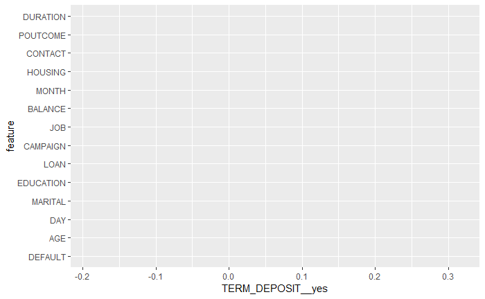

Now, we’re going to add a **v-line** which is just a line at the zero axis and this is just gonna help visually tell us where the correlations line them.

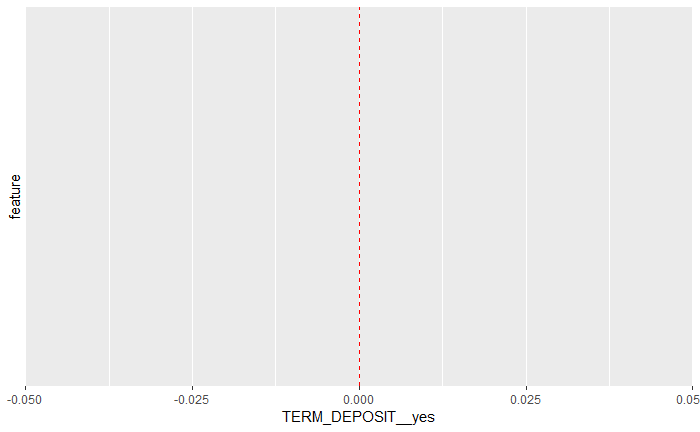

```r
# Geometries
geom_vline(xintercept = 0, linetype = 2, color = \red\)
```

Next thing we’re going to add some points, so what this is going to do is add the points to the visualization.

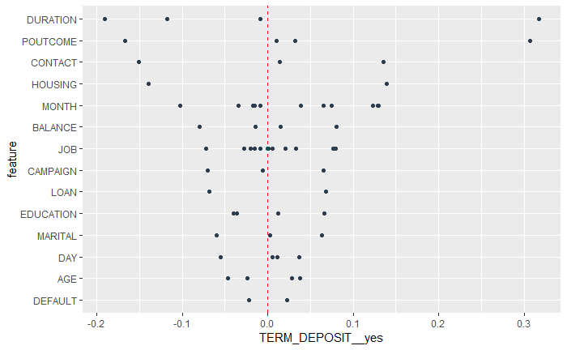

```r
ggplot(aes(TERM_DEPOSIT__yes, y = feature, text = bin)) +

# Geometries
geom_vline(xintercept = 0, linetype = 2, color = \red\) +
geom_point(color = \#2c3e50\)
```

Here, the next thing that we’re going to do is to use this function called **geom_txt_repel** and what this is going to do is, it’s going to add the text and all the lines so we can see you know which bins each point corresponds to and so on.

[figure not shown]

```r
ggplot(aes(TERM_DEPOSIT__yes, y = feature, text = bin)) +

# Geometries
geom_vline(xintercept = 0, linetype = 2, color = \red\) +
geom_point(color = \#2c3e50\) +
geom_text_repel(aes(label = bin), size = 3, color = \#2c3e50\)
```

In just a few lines of code, we’ve already got this **correlation funnel** visualization being developed and we can already see right here these are the the ones that we’ve want to focus on that are the most highly correlated to term deposit, duration and P outcome.

Just some formatting, so we’re going to expand the limits from **-0.4 to 0.4** on the x-axis.

[figure not shown]

```r
ggplot(aes(TERM_DEPOSIT__yes, y = feature, text = bin)) +

# Geometries
geom_vline(xintercept = 0, linetype = 2, color = \red\) +
geom_point(color = \#2c3e50\) +
geom_text_repel(aes(label = bin), size = 3, color = \#2c3e50\) +

# Formatting
expand_limits(x = c(-0.4, 0.4))
```

Here, we’re going to change up the theme using **tidyquant** theme, so that just gave it a white background.

[figure not shown]

```r
ggplot(aes(TERM_DEPOSIT__yes, y = feature, text = bin)) +

# Geometries
geom_vline(xintercept = 0, linetype = 2, color = \red\) +
geom_point(color = \#2c3e50\) +
geom_text_repel(aes(label = bin), size = 3, color = \#2c3e50\) +

# Formatting
expand_limits(x = c(-0.4, 0.4)) +
theme_tq()
```

We’ll add a few labels for formatting as well, this adds a title and a subtitle here and an x-axis title is converted into correlation to term deposit, it gets rid of the y-axis title. So right there we’ve got our visualization number one.

[figure not shown]

```r
ggplot(aes(TERM_DEPOSIT__yes, y = feature, text = bin)) +

# Geometries
geom_vline(xintercept = 0, linetype = 2, color = \red\) +
geom_point(color = \#2c3e50\) +
geom_text_repel(aes(label = bin), size = 3, color = \#2c3e50\) +

# Formatting
expand_limits(x = c(-0.4, 0.4)) +
theme_tq() +
labs(title = \Bank Marketing Analysis\,
     subtitle = \Correlations to Enrollment in Term Deposit\,
     y = \\, x = \Correlation to Term Deposit\)
```

### 5.7.3 Interpret Correlations

Now that we’ve got this information in hand, what we can do is then interpret the correlations.

We have bin 2, 3, 4 but that doesn’t really help us what we need to know is what’s in those bins. So this recipe object that we created which was used to create those bins, when you pipe that into this **tidy** function, it outputs a data frame that tells you each of the steps and has a step number and what we want to know is what happened inside of that discretize step.

`r`r recipe_obj %>% tidy()

| number | operation | type | trained | skip | id |
| --- | --- | --- | --- | --- | --- |
| 1 | step | rm | TRUE | FALSE | rm_5ECLs |
| 2 | step | discretize | TRUE | FALSE | discretize_dtGZX |
| 3 | step | dummy | TRUE | FALSE | dummy_VJbBo |

In step number 2, when we pipe it into the tidy function gives me each of the values of those bins so what I can then do is save this as a variable

`r`r bins_tbl <- recipe_obj %>% tidy(2)

`r`r bins_tbl

| terms | value | id |
| --- | --- | --- |
| AGE | -Inf | discretize_dtGZX |
| AGE | 33 | discretize_dtGZX |
| AGE | 39 | discretize_dtGZX |
| AGE | 48 | discretize_dtGZX |
| AGE | Inf | discretize_dtGZX |
| BALANCE | -Inf | discretize_dtGZX |
| BALANCE | 72 | discretize_dtGZX |
| BALANCE | 448 | discretize_dtGZX |
| BALANCE | 1428 | discretize_dtGZX |
| BALANCE | Inf | discretize_dtGZX |

[output cut: 18 more lines]

| terms | value | id |
| --- | --- | --- |
| DURATION | -Inf | discretize_dtGZX |
| DURATION | 103 | discretize_dtGZX |
| DURATION | 180 | discretize_dtGZX |
| DURATION | 319 | discretize_dtGZX |
| DURATION | Inf | discretize_dtGZX |

# 6. Strategy

## 6.1 Focus on DURATION bin4 and POUTCOME == success

We’ve got this data_join_tbl which is our untransformed data.

`r`r data_joined_tbl

| ID | AGE | JOB | MARITAL | EDUCATION | DEFAULT | BALANCE | HOUSING | LOAN | CONTACT | DAY | MONTH | DURATION | CAMPAIGN | PDAYS | PREVIOUS | POUTCOME | TERM_DEPOSIT |
| --- | --- | --- | --- | --- | --- | --- | --- | --- | --- | --- | --- | --- | --- | --- | --- | --- | --- |
| 2836 | 58 | management | married | tertiary | no | 2143 | yes | no | unknown | 5 | may | 261 | 1 | -1 | 0 | unknown | no |
| 2837 | 44 | technician | single | secondary | no | 29 | yes | no | unknown | 5 | may | 151 | 1 | -1 | 0 | unknown | no |
| 2838 | 33 | entrepreneur | married | secondary | no | 2 | yes | yes | unknown | 5 | may | 76 | 1 | -1 | 0 | unknown | no |
| 2839 | 47 | blue-collar | married | unknown | no | 1506 | yes | no | unknown | 5 | may | 92 | 1 | -1 | 0 | unknown | no |
| 2840 | 33 | unknown | single | unknown | no | 1 | no | no | unknown | 5 | may | 198 | 1 | -1 | 0 | unknown | no |
| 2841 | 35 | management | married | tertiary | no | 231 | yes | no | unknown | 5 | may | 139 | 1 | -1 | 0 | unknown | no |
| 2842 | 28 | management | single | tertiary | no | 447 | yes | yes | unknown | 5 | may | 217 | 1 | -1 | 0 | unknown | no |
| 2843 | 42 | entrepreneur | divorced | tertiary | yes | 2 | yes | no | unknown | 5 | may | 380 | 1 | -1 | 0 | unknown | no |
| 2844 | 58 | retired | married | primary | no | 121 | yes | no | unknown | 5 | may | 50 | 1 | -1 | 0 | unknown | no |
| 2845 | 43 | technician | single | secondary | no | 593 | yes | no | unknown | 5 | may | 55 | 1 | -1 | 0 | unknown | no |

[output cut: 990 more lines]

What we’re doing is that we’re selecting **DURATION**, **POUTCOME**, and then our target which is **TERM_DPOSIT**.

`r`r data_joined_tbl %>% select(DURATION, POUTCOME, TERM_DEPOSIT)

| DURATION | POUTCOME | TERM_DEPOSIT |
| --- | --- | --- |
| 261 | unknown | no |
| 151 | unknown | no |
| 76 | unknown | no |
| 92 | unknown | no |
| 198 | unknown | no |
| 139 | unknown | no |
| 217 | unknown | no |
| 380 | unknown | no |
| 50 | unknown | no |
| 55 | unknown | no |

[output cut: 990 more lines]

We have a new column here called **POTENTIAL** and we’ve classified people as **Normal** potential when they are not greater than 319 days and not equal to P outcome == success. So everybody gets normal unless they have this duration greater than 319 days, then they get this **High Potential** tag or P outcome == success then they get a high potential tag.

`r`r strategy_tbl

| DURATION | POUTCOME | TERM_DEPOSIT | POTENTIAL |
| --- | --- | --- | --- |
| 261 | unknown | no | Normal |
| 151 | unknown | no | Normal |
| 76 | unknown | no | Normal |
| 92 | unknown | no | Normal |
| 198 | unknown | no | Normal |
| 139 | unknown | no | Normal |
| 217 | unknown | no | Normal |
| 380 | unknown | no | High Potential |
| 50 | unknown | no | Normal |
| 55 | unknown | no | Normal |

[output cut: 990 more lines]

What we are going to do is assess the proportion or the probability, so we’re going to group by potential.

`r`r strategy_tbl

| DURATION | POUTCOME | TERM_DEPOSIT | POTENTIAL |
| --- | --- | --- | --- |
| 261 | unknown | no | Normal |
| 151 | unknown | no | Normal |
| 76 | unknown | no | Normal |
| 92 | unknown | no | Normal |
| 198 | unknown | no | Normal |
| 139 | unknown | no | Normal |
| 217 | unknown | no | Normal |
| 380 | unknown | no | High Potential |
| 50 | unknown | no | Normal |
| 55 | unknown | no | Normal |

[output cut: 990 more lines]

We’re then going to count the term deposits meaning **no’s** and **yes’s**.

`r`r strategy_tbl

| POTENTIAL | TERM_DEPOSIT | n |
| --- | --- | --- |
| High Potential | no | 8364 |
| High Potential | yes | 3887 |
| Normal | no | 31558 |
| Normal | yes | 1402 |

Then we’re going to add proportion on here.

`r`r strategy_tbl

| POTENTIAL | TERM_DEPOSIT | n | prop |
| --- | --- | --- | --- |
| High Potential | no | 8364 | 0.68271978 |
| High Potential | yes | 3887 | 0.31728022 |
| Normal | no | 31558 | 0.95746359 |
| Normal | yes | 1402 | 0.04253641 |

We’re getting **31%** yield out of this high potential group versus the normal group which is only **4%**.

`r`r strategy_tbl

| POTENTIAL | TERM_DEPOSIT | n | prop | label_text |
| --- | --- | --- | --- | --- |
| High Potential | no | 8364 | 0.68271978 | n: 8364\nprop: 68.3% |
| High Potential | yes | 3887 | 0.31728022 | n: 3887\nprop: 31.7% |
| Normal | no | 31558 | 0.95746359 | n: 31558\nprop: 95.7% |
| Normal | yes | 1402 | 0.04253641 | n: 1402\nprop: 4.3% |

## 6.2 Report Results

It seems like there’s going to be a strong likelihood that we’re going to be able to increase the yield to 31% versus **4.3%** percent and that was basically just with a simple correlation analysis implementing a business process.

We do want to show you the R markdown and this is cool because once you create that file you can actually integrate it into a file that contains it’s called R markdown but it has text so what we did was we copied and pasted the code in here and the visualization code and we added a little bit of text here and then click knit button it pulls up an actual report that we could give to boss and this is what their report looks like so it’s got the strategy here it’s got kind of executive summary.

Also, if you say, you’re not giving it to boss but, you give it to another data scientist, we can change this **echo** from false to true and rerun the document and it’ll actually have the code in there too.